# Molusco abalone

Gabriel de Jesus Pereira

2024-06-06

# Introdução

## O que são os abalones

- É um molusco gastrópode, podendo ser pequeno ou grande;
- Servem como alimento e joias para os seres humanos, sendo a China o principal consumidor

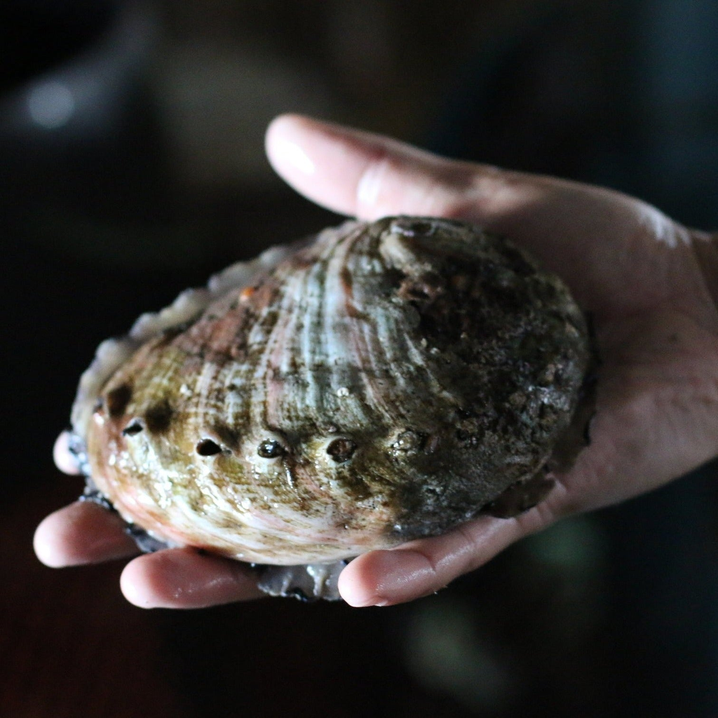

## Sobre o banco de dados

- É um banco de dados da área de biologia que contém medidas físicas de um abalone;
- O banco de dados contém 4177 observações;
- 8 colunas, sendo uma delas nominal e o restante numérica;
- Foi criado por Warwick Nash, Tracy Sellers, Simon Talbot, Andrew Cawthorn, Wes Ford.

## As variáveis do banco de dados

- Sexo do abalone: variável nominal indicando se o abalone é macho, fêmea ou filhote.
- Length: Medição do maior comprimento da concha
- Diameter: perpendicular ao comprimento
- Height: com carne na casca

## As variáveis do banco de dados

- Whole weight: abalone inteiro
- Shucked weight: peso da carne
- Viscera weight: peso das vísceras
- Shell weight: peso da concha sem carne

# Objetivo

Analisar os dados de abalones utilizando métodos descritivos, fatoriais e de componentes principais.

# Leitura dos dados

```r
data <- readr::read_csv("abalone.csv") |>
  mutate(
    Sex = case_when(
      Sex == "F" ~ "Fêmea",
      Sex == "M" ~ "Macho",
      TRUE ~ "Filhote"
      )
    ) |>
  select(- Rings)
```

# Análise Exploratória

## Valores ausentes

- Código
- Valores ausentes

```r
Ausentes <- data |>
  vis_dat() +
  labs(
    y = "Observações"
    ) +
  scale_fill_manual(
    values = viridis::mako(10)[5:6],
    labels = c("Qualitativa", "Quantitativa")
    ) +
  theme(
    legend.position = "bottom",
    legend.title = element_blank(),
  )
```

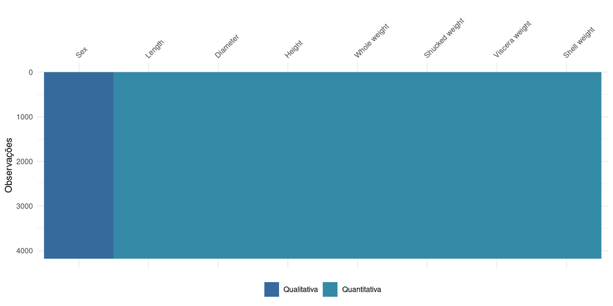

## Valores ausentes

- Observando todas as variáveis do banco de dados pelo gráfico, vemos que o banco de dados não possui valores ausentes;
- Podemos também ver o tipo de cada uma das variáveis do banco de dados.

## Frequência de cada sexo

- Código
- Frequência

```r
Frequência <- data |>
  ggplot(aes(x = forcats::fct_infreq(Sex))) +
  geom_bar(
        aes(
          y = after_stat(count) / sum(after_stat(count)),
          fill = Sex
          ),
        show.legend = FALSE,
  ) +
  theme_bw() +
  theme(axis.title.x = element_blank()) +
  scale_fill_manual(
    values = viridis::mako(5)[3:5]
    ) +
  labs(y = NULL, x = NULL)
```

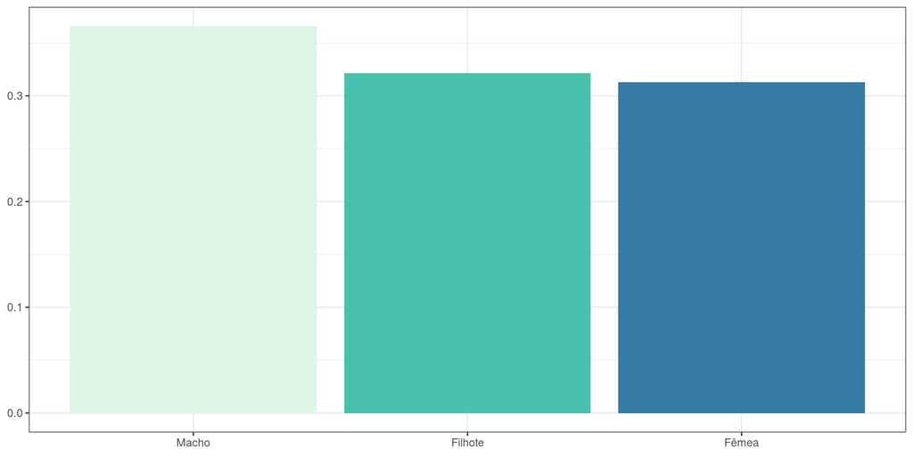

## Distribuições

- Código
- Distribuição

```r
Distribuição <- data |>
  pivot_longer(
    !Sex,
    names_to = "variable",
    values_to = "values"
  ) |>
  ggplot(
    aes(
      x = values,
      fill = Sex
      )
    ) +
  geom_violin(
    aes(y = variable),
    draw_quantiles = c(0.25, 0.5, 0.75),
    ) +
  labs(x = "", y = "") +
  facet_wrap(vars(variable), scales = "free") +
  scale_fill_manual(
    values = viridis::mako(5)[3:5],
    name = "Sexo"
    ) +
  theme_bw() +
  theme(axis.text.y = element_blank())
```

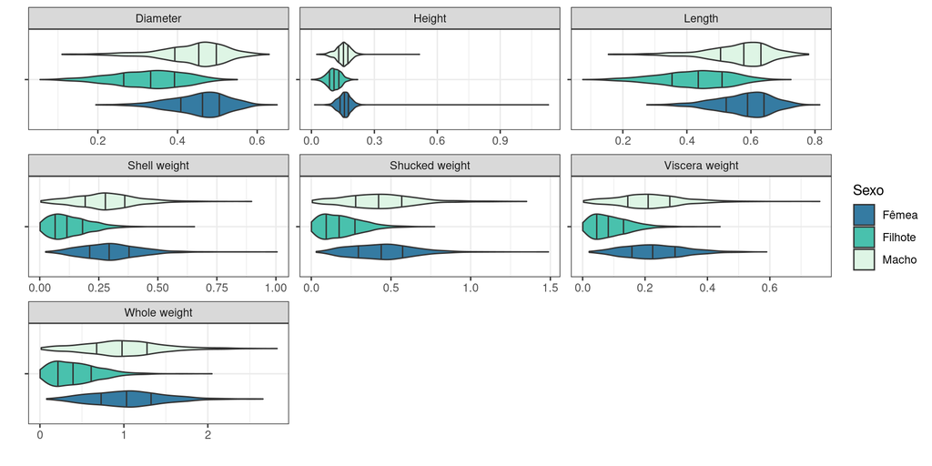

## Correlação

- Código
- Matriz de correlação

```r
data <- data |>
  (\(x) {
     scaled <- x |>
       select_if(is.numeric) |>
       scale() |>
       as_tibble()

     x |>
       select_if(is.character) |>
       cbind(scaled)
  })()

data |>
  select_if(is.numeric) |>
  cor() |>
  corrplot(
      method="circle",
      col = mako(200),
      diag = FALSE,
      addgrid.col = "#00000040",
      tl.pos = "l",
      tl.cex = 0.6,
      tl.col = "black",
      tl.offset = 0.25,
      cl.length = 9,
      cl.cex = 0.6,
      cl.ratio = 0.25,
      family = "mono"
  )
```

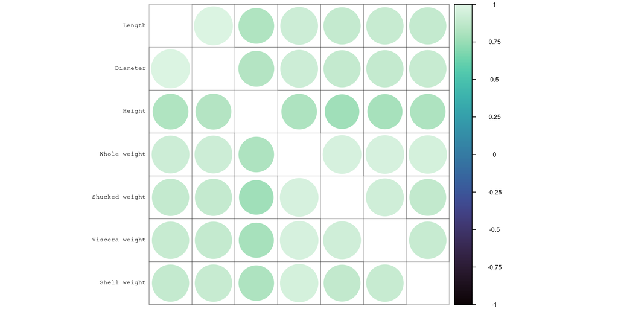

## Correlação

As variáveis têm uma correlação significativa entre si, sendo o comprimento da concha e o diâmetro as mais correlacionadas. Além disso, perceba que a relação entre as medidas corporais do molusco é diretamente proporcional.

# Componentes Principais

## Variância explicada por componente

- Código
- Componentes

```r
Componentes <- prcomp(
  data |>
    select_if(is.numeric),
  center = TRUE, tol=0
  )

Var <- fviz_eig(
  Componentes,
  addlabels = TRUE,
  barfill="#002951"
  ) +
  labs(
    y = "Porcentagem da variância explicada",
    x = "Componentes",
    title = ""
    )
```

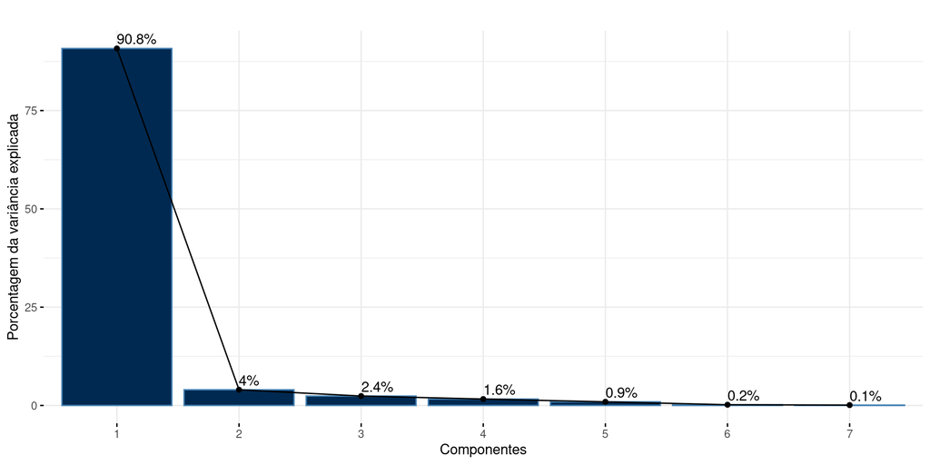

## Variância explicada por componente

- Podemos ver que o primeiro componente é aquele que mais explica a variância;
- A proporção acumulada do primeiro componente com o segundo componente chega aos 94,8%.

## Contribuição das variáveis

- Código
- Contribuição

```r
Contrib <- fviz_cos2(
  Componentes,
  choice = "var",
  axes = 1:2,
  fill="#002951"
  ) +
  labs(
    y = "Representação",
    title = ""
    )
```

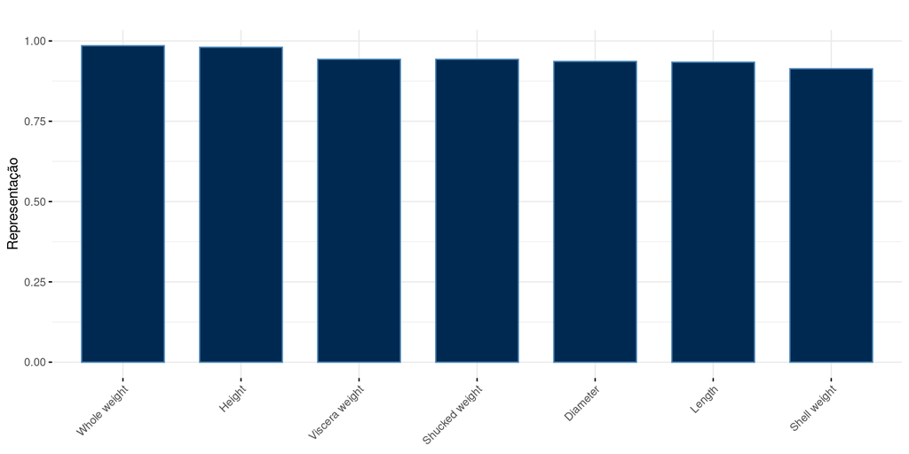

## Contribuição das variáveis

- As duas variáveis que mais contribuem para a formação das dimensões são o peso e a altura do abalone;
- As duas que menos contribuem são o peso da casca e a medição do comprimento da concha.

## Interpretação das componentes

- Código
- Componentes

```r
auto <- autoplot(
  Componentes,
  data = data,
  col="#444444",
  label.colour = "#002951",
  colour = "Sex",
  label = FALSE,
  label.size = 2,
  loadings = TRUE,
  loadings.colour = "#777777",
  loadings.label = TRUE,
  loadings.label.colour = "black",
  loadings.label.size = 4
  ) +
  theme_bw() +
  scale_color_manual(values = viridis::mako(5)[3:5],
                     name = "Sexo")
```

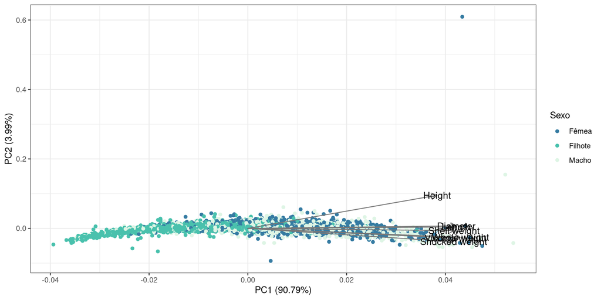

## Interpretação das componentes

- Analisando o PC1, vemos que as medidas do abalone são diretamente proporcionais a dimensão 1, mas podemos concluir também que os filhotes são aqueles com as menores medidas;
- Para o PC2, alguns pontos extremos podem ser responsáveis por boa parte da variabilidade de sua componente.

# Análise Fatorial

## Interpretação dos fatores

- Código
- Fatores

```r
Fator <- factanal(
  data |> select_if(is.numeric),
  factors = 2,
  scores="regression",
  nstart = 10
  )

auto <- autoplot(
  Fator,
  data = data,
  colour = "Sex",
  label = FALSE,
  loadings = TRUE,
  loadings.colour = "#444444",
  loadings.label = TRUE,
  loadings.label.colour = "black",
  label.colour = "black",
  loadings.label.size = 5
  ) +
  theme_bw() +
  scale_color_manual(values = viridis::mako(5)[3:5],
                     name = "Sexo")
```

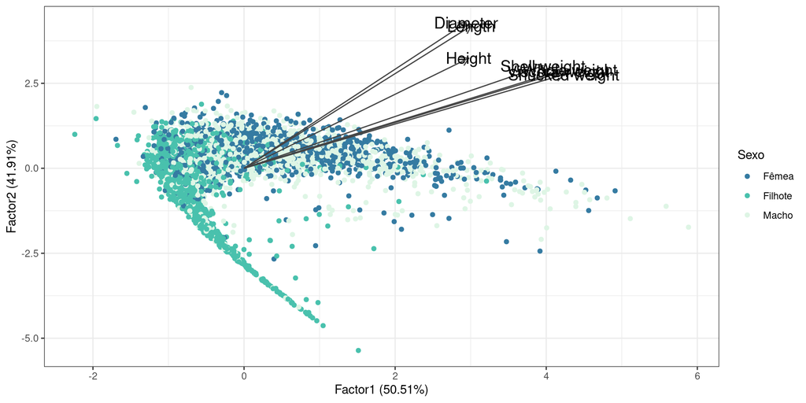

## Interpretação dos fatores

- Vemos que alguns dos filhotes estão concentrados na faixa do segundo fator, que é o fator com as menores medidas;
- O fator 1 está diretamente relacionado às medidas dos abalones.

# Considerações Finais

- As duas primeiras componentes explicam 94.779% da variância total. Vimos também que a primeira componente está diretamente relacionada às medidas corporais dos abalones.
- Para a análise fatorial, podemos observar que 2 fatores explicam 92.4% da variância total, sendo o fator 1 relacionado às maiores medidas dos abalones. Além disso, percebemos que alguns dos filhotes estão representados na faixa do fator 2, que é aquele que possui as menores medidas.